# Why is Stochastic Lambda > Deterministic?

Eric R. Scott

2022-04-21

# 1 TODO

- Instead of deterministic IPM using different vital rates models, use the random effects models, but plug in `newdata = (log_size_prev = log_size, year = "newlevel")` to get mean fitted values.
- Plot population trajectories for all models
- Read Rees & Ellner 2009. Consider either fixed effect of year + kernel sampling OR random effect of year + parameter sampling. Maybe no added value for random effect of year + kernel sampling??

Rees, Mark, and Stephen P. Ellner. “Integral Projection Models for Populations in Temporally Varying Environments.” Ecological Monographs 79, no. 4 (2009): 575–94. https://doi.org/10.1890/08-1474.1.

*Last compiled: 2022-05-03*

# 2 Purpose

Figure out what the heck is going on.

# 3 Load Data

# 4 Pick two years, worst and best

Fit determinsitic IPMs to all years separately to identify a bad year and a good year. Then subset data to only contain those years

```r
single_years <-
  data_full %>%
  filter(year>1999) %>%
  group_by(year_fct) %>%
  group_split()

#fit vital rates for FF
vit_list_yr_ff <-
  single_years %>%
  map(~dplyr::filter(.x, habitat == "1-ha")) %>%
  map(~{
    vit_list_det = c(
      list(
        vit_surv = surv_det(.x),
        vit_size = size_det(.x),
        vit_flwr = flwr_det(.x),
        vit_size_sdlg = size_sdlg_det(.x),
        vit_surv_sdlg = surv_sdlg_det(.x)
      ),
      vit_other_ff)
    })
# make IPMs for FF
ipms_yr_ff <-
  map(vit_list_yr_ff, ~{
    make_proto_ipm_det(.x, pop_vec = pop_vec_ff) %>%
      make_ipm(iterations = 1000,  #only needs 100 to converge
               normalize_pop_size = FALSE, # to run as PVA
               usr_funs = list(get_scat_params = get_scat_params))
  })

# fit vital rates for CF
vit_list_yr_cf <-
  single_years %>%
  map(~dplyr::filter(.x, habitat == "CF")) %>%
  map(~{
    vit_list_det = c(
      list(
        vit_surv = surv_det(.x),
        vit_size = size_det(.x),
        vit_flwr = flwr_det(.x),
        vit_size_sdlg = size_sdlg_det(.x),
        vit_surv_sdlg = surv_sdlg_det(.x)
      ),
      vit_other_cf)
    })

#make IPMs for CF
ipms_yr_cf <-
  map(vit_list_yr_cf, ~{
    make_proto_ipm_det(.x, pop_vec = pop_vec_cf) %>%
      make_ipm(iterations = 1000,  #only needs 100 to converge
               normalize_pop_size = FALSE, # to run as PVA
               usr_funs = list(get_scat_params = get_scat_params))
  })

#lambdas
lambdas_ff <- ipms_yr_ff %>% map_dbl(lambda)
lambdas_cf <- ipms_yr_cf %>% map_dbl(lambda)
```

```r
#worst year
(worst_year_ff <- c(2000:max(data_full$year))[which.min(lambdas_ff)]); min(lambdas_ff)
```

```
## [1] 2003
```

```
## [1] 0.9397404
```

```r
(worst_year_cf <- c(2000:max(data_full$year))[which.min(lambdas_cf)]); min(lambdas_cf)
```

```
## [1] 2003
```

```
## [1] 0.8810649
```

```r
#best year
(best_year_ff <- c(2000:max(data_full$year))[which.max(lambdas_ff)]); max(lambdas_ff)
```

```
## [1] 2001
```

```
## [1] 1.005335
```

```r
(best_year_cf <- c(2000:max(data_full$year))[which.max(lambdas_cf)]); max(lambdas_cf)
```

```
## [1] 2002
```

```
## [1] 1.027696
```

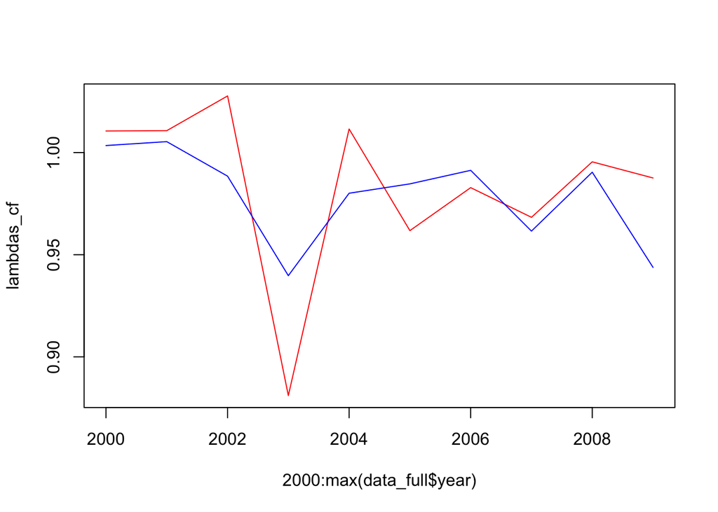

```r
plot(2000:max(data_full$year), lambdas_cf, type = "l", col = "red"); lines(x =2000:max(data_full$year), y = lambdas_ff, col = "blue", type = "l")
```

2003 was the worst year in both habitats. 2001 was a good year in both habitats (but not the best in CF)

```r
#combine good and bad year
two_yrs <- data_full %>% filter(year %in% c(2003, 2001))
two_yrs_ff <- two_yrs %>% filter(habitat == "1-ha")
two_yrs_cf <- two_yrs %>% filter(habitat == "CF")
```

# 5 Fit IPMs

## 5.1 Deterministic

Fit a deterministic IPM with just those two years of data

Fragments:

```r
vit_list_det_ff = c(
  list(
    vit_surv = surv_det(two_yrs_ff),
    vit_size = size_det(two_yrs_ff),
    vit_flwr = flwr_det(two_yrs_ff),
    vit_size_sdlg = size_sdlg_det(two_yrs_ff),
    vit_surv_sdlg = surv_sdlg_det(two_yrs_ff)
  ),
  vit_other_ff)

ipm_det_ff = make_proto_ipm_det(vit_list_det_ff, pop_vec = pop_vec_ff) %>%
  make_ipm(iterations = 1000,  #only needs 100 to converge
           normalize_pop_size = FALSE, # to run as PVA
           usr_funs = list(get_scat_params = get_scat_params))
# FF
lambda(ipm_det_ff)
```

```
##    lambda
## 0.9644405
```

CF:

```r
vit_list_det_cf = c(
  list(
    vit_surv = surv_det(two_yrs_cf),
    vit_size = size_det(two_yrs_cf),
    vit_flwr = flwr_det(two_yrs_cf),
    vit_size_sdlg = size_sdlg_det(two_yrs_cf),
    vit_surv_sdlg = surv_sdlg_det(two_yrs_cf)
  ),
  vit_other_cf)

ipm_det_cf = make_proto_ipm_det(vit_list_det_cf, pop_vec = pop_vec_cf) %>%
  make_ipm(iterations = 1000,  #only needs 100 to converge
           normalize_pop_size = FALSE, # to run as PVA
           usr_funs = list(get_scat_params = get_scat_params))
lambda(ipm_det_cf)
```

```
##    lambda
## 0.9529791
```

## 5.2 Stochastic

The stochastic IPM requires re-writing the `proto_ipm` because it’s now using different parameter sets for year. This now uses vital rates models where there is a random effect of year fit such that each year can have a different shape smoother (but not different wiggliness).

```r
## forests fragments
vit_list_stoch_ff = c(
  list(
    vit_surv = surv_raneff(two_yrs_ff),
    vit_size = size_raneff(two_yrs_ff),
    vit_flwr = flwr_raneff(two_yrs_ff),
    vit_size_sdlg = size_sdlg_raneff(two_yrs_ff),
    vit_surv_sdlg = surv_sdlg_raneff(two_yrs_ff)
  ),
  vit_other_ff)

proto_ipm_stoch_ff <-
  init_ipm(
    sim_gen = "general",
    di_dd = "di",
    det_stoch = "stoch",
    kern_param = "kern"
  ) %>%

  # Define growth and survival kernel
  define_kernel(
    "P_yr", #_yr makes a different P kernel for each value of `yr` from par_set_indices
    formula = s_z * G_z1z * d_log_size,
    family  = "CC",
    # Probability of survival
    s_z = predict(vit_surv,
                  newdata = tibble(log_size_prev = log_size_1, year_fct = yr),
                  type = 'response'),
    # Growth
    G_z1z = dt.scaled(
      log_size_2,
      df   = size_nu,
      mean = size_mu,
      sd   = size_sd
    ),
    size_mu = predict(vit_size,
                      newdata = tibble(log_size_prev = log_size_1, year_fct = yr),
                      type = 'response'),
    size_nu = get_scat_params(vit_size)["nu"],
    size_sd = get_scat_params(vit_size)["sd"],

    data_list = vit_list_stoch_ff,
    states          = list(c('log_size')),
    uses_par_sets   = TRUE,
    par_set_indices = list(yr = c(2001, 2003)),
    evict_cor       = TRUE,
    evict_fun       = truncated_distributions("t.scaled", "G_z1z")
  ) %>%

  # Define fecundity and recruitment kernel
  define_kernel(
    "go_sdlg_yr",
    formula = p_f * fruits * seeds * g_e * d_log_size,
    family  = "CD",
    # probability of flowering
    p_f = predict(vit_flwr,
                  newdata = tibble(log_size_prev = log_size_1, year_fct = yr),
                  type = 'response'),
    fruits = predict(vit_fruits,
                     newdata = tibble(log_size_prev = log_size_1),
                     type = 'response'),
    seeds = exp(coef(vit_seeds)[1]), #mean seeds per fruit
    g_e = vit_germ_est,

    data_list     = vit_list_stoch_ff,
    states        = list(c('log_size', 'sdlg')),
    uses_par_sets = TRUE,
    par_set_indices = list(yr = c(2001, 2003))
  ) %>%

  define_kernel(
    name = "stay_sdlg",
    formula = 0,
    family = "DD",
    states = list(c("sdlg")),
    evict_cor = FALSE
  ) %>%

  # Enter into post-seedling
  define_kernel(
    name = "leave_sdlg_yr",
    formula = s_sdlg * G_z2_sdlg,
    family = "DC",
    s_sdlg = predict(vit_surv_sdlg,
                     newdata = tibble(year_fct = yr),
                     type = 'response'), #intercept from intercept-only glm
    G_z2_sdlg = dt.scaled(
      x    = log_size_2,
      df   = size_sdlg_nu,
      mean = size_sdlg_mu,
      sd   = size_sdlg_sd
    ),
    size_sdlg_mu = coef(vit_size_sdlg)[1], #intercept from intercept-only glm
    size_sdlg_nu = get_scat_params(vit_size_sdlg)["nu"],
    size_sdlg_sd = get_scat_params(vit_size_sdlg)["sd"],

    data_list = vit_list_stoch_ff,
    states = list(c("sdlg", "log_size")),
    uses_par_sets = TRUE,
    par_set_indices = list(yr = c(2001, 2003)),
    evict_cor = TRUE,
    evict_fun = truncated_distributions("t.scaled", "G_z2_sdlg")
  ) %>%

  # define implementation with midpoint rule
  define_impl(make_impl_args_list(
    kernel_names = c("P_yr",        "go_sdlg_yr", "stay_sdlg", "leave_sdlg_yr"),
    int_rule = "midpoint",
    state_start  = c("log_size", "log_size", "sdlg",     "sdlg"),
    state_end    = c("log_size", "sdlg",     "sdlg",     "log_size")
  )) %>%
  #define lower bound, upper bound, and number of meshpoints for log_size
  define_domains(log_size = c(0, 8.018296, 100)) %>%
  #arbitrary starting population state
  define_pop_state(pop_vectors = pop_vec_ff)
```

```r
## forests fragments
vit_list_stoch_cf = c(
  list(
    vit_surv = surv_raneff(two_yrs_cf),
    vit_size = size_raneff(two_yrs_cf),
    vit_flwr = flwr_raneff(two_yrs_cf),
    vit_size_sdlg = size_sdlg_raneff(two_yrs_cf),
    vit_surv_sdlg = surv_sdlg_raneff(two_yrs_cf)
  ),
  vit_other_cf)

proto_ipm_stoch_cf <-
  init_ipm(
    sim_gen = "general",
    di_dd = "di",
    det_stoch = "stoch",
    kern_param = "kern"
  ) %>%

  # Define growth and survival kernel
  define_kernel(
    "P_yr", #_yr makes a different P kernel for each value of `yr` from par_set_indices
    formula = s_z * G_z1z * d_log_size,
    family  = "CC",
    # Probability of survival
    s_z = predict(vit_surv,
                  newdata = tibble(log_size_prev = log_size_1, year_fct = yr),
                  type = 'response'),
    # Growth
    G_z1z = dt.scaled(
      log_size_2,
      df   = size_nu,
      mean = size_mu,
      sd   = size_sd
    ),
    size_mu = predict(vit_size,
                      newdata = tibble(log_size_prev = log_size_1, year_fct = yr),
                      type = 'response'),
    size_nu = get_scat_params(vit_size)["nu"],
    size_sd = get_scat_params(vit_size)["sd"],

    data_list = vit_list_stoch_cf,
    states          = list(c('log_size')),
    uses_par_sets   = TRUE,
    par_set_indices = list(yr = c(2001, 2003)),
    evict_cor       = TRUE,
    evict_fun       = truncated_distributions("t.scaled", "G_z1z")
  ) %>%

  # Define fecundity and recruitment kernel
  define_kernel(
    "go_sdlg_yr",
    formula = p_f * fruits * seeds * g_e * d_log_size,
    family  = "CD",
    # probability of flowering
    p_f = predict(vit_flwr,
                  newdata = tibble(log_size_prev = log_size_1, year_fct = yr),
                  type = 'response'),
    fruits = predict(vit_fruits,
                     newdata = tibble(log_size_prev = log_size_1),
                     type = 'response'),
    seeds = exp(coef(vit_seeds)[1]), #mean seeds per fruit
    g_e = vit_germ_est,

    data_list     = vit_list_stoch_cf,
    states        = list(c('log_size', 'sdlg')),
    uses_par_sets = TRUE,
    par_set_indices = list(yr = c(2001, 2003))
  ) %>%

  define_kernel(
    name = "stay_sdlg",
    formula = 0,
    family = "DD",
    states = list(c("sdlg")),
    evict_cor = FALSE
  ) %>%

  # Enter into post-seedling
  define_kernel(
    name = "leave_sdlg_yr",
    formula = s_sdlg * G_z2_sdlg,
    family = "DC",
    s_sdlg = predict(vit_surv_sdlg,
                     newdata = tibble(year_fct = yr),
                     type = 'response'), #intercept from intercept-only glm
    G_z2_sdlg = dt.scaled(
      x    = log_size_2,
      df   = size_sdlg_nu,
      mean = size_sdlg_mu,
      sd   = size_sdlg_sd
    ),
    size_sdlg_mu = coef(vit_size_sdlg)[1], #intercept from intercept-only glm
    size_sdlg_nu = get_scat_params(vit_size_sdlg)["nu"],
    size_sdlg_sd = get_scat_params(vit_size_sdlg)["sd"],

    data_list = vit_list_stoch_cf,
    states = list(c("sdlg", "log_size")),
    uses_par_sets = TRUE,
    par_set_indices = list(yr = c(2001, 2003)),
    evict_cor = TRUE,
    evict_fun = truncated_distributions("t.scaled", "G_z2_sdlg")
  ) %>%

  # define implementation with midpoint rule
  define_impl(make_impl_args_list(
    kernel_names = c("P_yr",        "go_sdlg_yr", "stay_sdlg", "leave_sdlg_yr"),
    int_rule = "midpoint",
    state_start  = c("log_size", "log_size", "sdlg",     "sdlg"),
    state_end    = c("log_size", "sdlg",     "sdlg",     "log_size")
  )) %>%
  #define lower bound, upper bound, and number of meshpoints for log_size
  define_domains(log_size = c(0, 8.018296, 100)) %>%
  #arbitrary starting population state
  define_pop_state(pop_vectors = pop_vec_cf)
```

Iterate IPM with 1000 iterations

```r
year_seq = sample(c(2001, 2003), size = 1000, replace = TRUE)
```

```r
ipm_stoch_ff <-
  proto_ipm_stoch_ff %>%
  make_ipm(iterations = 1000,
           normalize_pop_size = FALSE, # to run as PVA
           kernel_seq = as.character(year_seq),
           usr_funs = list(get_scat_params = get_scat_params))

ipm_stoch_cf <-
  proto_ipm_stoch_cf %>%
  make_ipm(iterations = 1000,
           normalize_pop_size = FALSE, # to run as PVA
           kernel_seq = as.character(year_seq),
           usr_funs = list(get_scat_params = get_scat_params))
```

# 6 Investigation

First, with just the worst and best years, is the stochastic lambda still higher than the deterministic?

```r
all_lams <-
  list(ff = ipm_stoch_ff, cf = ipm_stoch_cf) %>%
  map_df(
    ~tibble(year = .x$env_seq,
         lambda = lambda(.x, type_lambda = "all")[,1])%>%
  #remove burnin
  slice(101:n()),
  .id = "habitat"
  )
```

```r
tribble(~model, ~habitat, ~year, ~lambda,
        "det", "ff", "both combined", lambda(ipm_det_ff),
        "stoch", "ff", "both combined", lambda(ipm_stoch_ff, log = FALSE),
        "det", "cf", "both combined", lambda(ipm_det_cf),
        "stoch", "cf", "both combined", lambda(ipm_stoch_ff, log = FALSE),
        "det", "ff", "2001", lambdas_ff[2],
        "det", "ff", "2003", lambdas_ff[4],
        "det", "cf", "2001", lambdas_cf[2],
        "det", "cf", "2003", lambdas_cf[4]
) %>%
  bind_rows(
    all_lams %>%
      group_by(habitat, year) %>%
      summarize(lambda = mean(lambda)) %>%
      mutate(year = paste(year, "mean"),
             model = "stoch")
  ) %>% arrange(model, habitat)
```

```
## # A tibble: 12 × 4
##    model habitat year          lambda
##    <chr> <chr>   <chr>          <dbl>
##  1 det   cf      both combined  0.953
##  2 det   cf      2001           1.01
##  3 det   cf      2003           0.881
##  4 det   ff      both combined  0.964
##  5 det   ff      2001           1.01
##  6 det   ff      2003           0.940
##  7 stoch cf      both combined  0.965
##  8 stoch cf      2001 mean      0.973
##  9 stoch cf      2003 mean      0.952
## 10 stoch ff      both combined  0.965
## 11 stoch ff      2001 mean      0.966
## 12 stoch ff      2003 mean      0.964
```

Stochastic lambda is still slightly higher than deterministic

The deterministic lambda for 2001 is a lot higher than the mean of the 2001 lambdas from the stochastic simulation and the deterministic lambda for 2003 is a lot lower than the mean of the 2003 lambdas from the stochastic simulation. This makes sense to me, as fitting year as a random effect rather than a fixed effect will shrink estimates toward a global mean.

How do they compare at the level of vital rates?

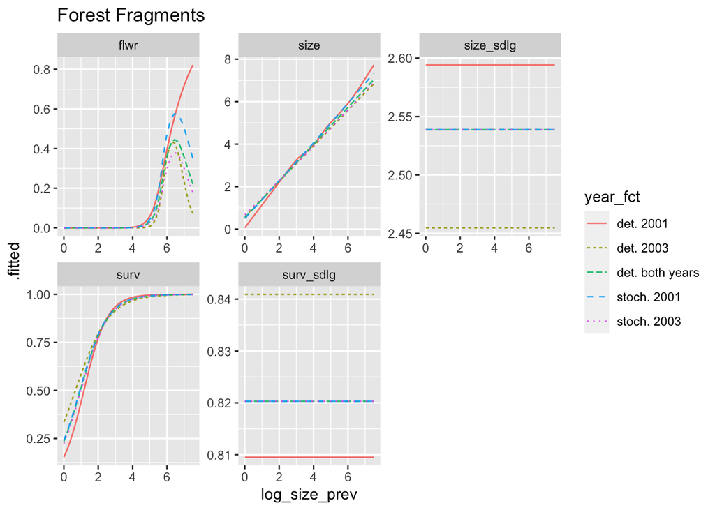

```r
newdata <- expand.grid(
  log_size_prev = seq(min(two_yrs$log_size_prev, na.rm = TRUE), max(two_yrs$log_size_prev, na.rm = TRUE), length.out = 50),
  year_fct = as.character(c(2001, 2003))
)

safe_predict <- possibly(predict, NA)

#deterministic, just 2001
det_fitted_2001_ff <-
  vit_list_yr_ff[[2]] %>%
  map_df(~safe_predict(.x, newdata = newdata, type = "response")) %>%
  bind_cols(newdata) %>%
  select(-vit_fruits, -vit_seeds, -vit_germ_est) %>%
  pivot_longer(starts_with("vit_"), names_to = "vital_rate", values_to = ".fitted", names_prefix = "vit_") %>%
  mutate(year_fct = "det. 2001")

#deterministic, just 2003
det_fitted_2003_ff <-
  vit_list_yr_ff[[4]] %>%
  map_df(~safe_predict(.x, newdata = newdata, type = "response")) %>%
  bind_cols(newdata) %>%
  select(-vit_fruits, -vit_seeds, -vit_germ_est) %>%
  pivot_longer(starts_with("vit_"), names_to = "vital_rate", values_to = ".fitted", names_prefix = "vit_") %>%
  mutate(year_fct = "det. 2003")

#deterministic with both years combined
det_fitted_ff <-
  vit_list_det_ff %>%
  map_df(~safe_predict(.x, newdata = newdata, type = "response")) %>%
  bind_cols(newdata) %>%
  select(-vit_fruits, -vit_seeds, -vit_germ_est) %>%
  pivot_longer(starts_with("vit_"), names_to = "vital_rate", values_to = ".fitted", names_prefix = "vit_") %>%
  mutate(year_fct = "det. both years")

#stochastic
stoch_fitted_ff <-
  vit_list_stoch_ff %>%
  map_df(~safe_predict(.x, newdata= newdata, type = "response")) %>%
  bind_cols(newdata) %>%
  select(-vit_fruits, -vit_seeds, -vit_germ_est) %>%
  pivot_longer(starts_with("vit_"), names_to = "vital_rate", values_to = ".fitted", names_prefix = "vit_") %>%
  mutate(year_fct = paste("stoch.", year_fct))

bind_rows(stoch_fitted_ff, det_fitted_ff, det_fitted_2001_ff, det_fitted_2003_ff) %>%
  ggplot(aes(x = log_size_prev, y = .fitted, color = year_fct, linetype = year_fct)) +
  geom_line(alpha = 0.9) +
  facet_wrap(~vital_rate, scales = "free") +
  labs(title = "Forest Fragments")
```

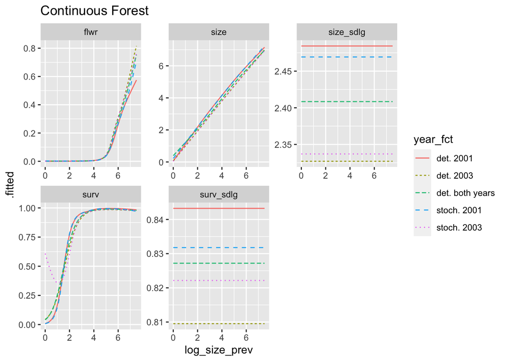

```r
newdata <- expand.grid(
  log_size_prev = seq(min(two_yrs$log_size_prev, na.rm = TRUE), max(two_yrs$log_size_prev, na.rm = TRUE), length.out = 50),
  year_fct = as.character(c(2001, 2003))
)

safe_predict <- possibly(predict, NA)

#deterministic, just 2001
det_fitted_2001_cf <-
  vit_list_yr_cf[[2]] %>%
  map_df(~safe_predict(.x, newdata = newdata, type = "response")) %>%
  bind_cols(newdata) %>%
  select(-vit_fruits, -vit_seeds, -vit_germ_est) %>%
  pivot_longer(starts_with("vit_"), names_to = "vital_rate", values_to = ".fitted", names_prefix = "vit_") %>%
  mutate(year_fct = "det. 2001")

#deterministic, just 2003
det_fitted_2003_cf <-
  vit_list_yr_cf[[4]] %>%
  map_df(~safe_predict(.x, newdata = newdata, type = "response")) %>%
  bind_cols(newdata) %>%
  select(-vit_fruits, -vit_seeds, -vit_germ_est) %>%
  pivot_longer(starts_with("vit_"), names_to = "vital_rate", values_to = ".fitted", names_prefix = "vit_") %>%
  mutate(year_fct = "det. 2003")

#deterministic with both years combined
det_fitted_cf <-
  vit_list_det_cf %>%
  map_df(~safe_predict(.x, newdata = newdata, type = "response")) %>%
  bind_cols(newdata) %>%
  select(-vit_fruits, -vit_seeds, -vit_germ_est) %>%
  pivot_longer(starts_with("vit_"), names_to = "vital_rate", values_to = ".fitted", names_prefix = "vit_") %>%
  mutate(year_fct = "det. both years")

#stochastic
stoch_fitted_cf <-
  vit_list_stoch_cf %>%
  map_df(~safe_predict(.x, newdata= newdata, type = "response")) %>%
  bind_cols(newdata) %>%
  select(-vit_fruits, -vit_seeds, -vit_germ_est) %>%
  pivot_longer(starts_with("vit_"), names_to = "vital_rate", values_to = ".fitted", names_prefix = "vit_") %>%
  mutate(year_fct = paste("stoch.", year_fct))

bind_rows(stoch_fitted_cf, det_fitted_cf, det_fitted_2001_cf, det_fitted_2003_cf) %>%
  ggplot(aes(x = log_size_prev, y = .fitted, color = year_fct, linetype = year_fct)) +
  geom_line(alpha = 0.9) +
  facet_wrap(~vital_rate, scales = "free") +
  labs(title = "Continuous Forest")
```